# A Machine Model for Predicting Barbell Lifts

Shep Smithline

July 14, 2014

### I. Introduction

In this paper we decribe the use of the use of the random forest model to predict successfully whether barbell lifts are done correctly. The random forest model is an example of a tree based classicification method. In a tree based classicfication method the space spanned by the individual predictors is divided into discrete nonoverlaping regions regions. For each of these regions we determine the most commonly occuring class and this class becomes the prediction for our model. In our case, the class variable is manner in which the exercise is done - the classe variable in the data set.

### II. Data Selection and Model Building

We read the data in

```r
training<-read.csv("pml-training.csv")
```

and noticed that a large number of columns had “NAs” or “DIV/0!” which make them nonsuitable for prediction. In addition, a number of columns clearly contain irrelvant data (eg user names) so we decided to restrict ourselves to a subset of the data:

“num_window” “roll_belt” “pitch_belt” “yaw_belt” “total_accel_belt” “gyros_belt_x” “gyros_belt_y” “gyros_belt_z” “accel_belt_x” “accel_belt_y” “accel_belt_z” “magnet_belt_x” “magnet_belt_y” “magnet_belt_z” “roll_arm”  
“pitch_arm” “yaw_arm” “total_accel_arm” “gyros_arm_x” “gyros_arm_y”  
“gyros_arm_z” “accel_arm_x” “accel_arm_y” “accel_arm_z” “magnet_arm_x” “magnet_arm_y” “magnet_arm_z” “roll_dumbbell” “pitch_dumbbell” “yaw_dumbbell”  
“gyros_dumbbell_x” “gyros_dumbbell_y” “gyros_dumbbell_z” “accel_dumbbell_x” “accel_dumbbell_y” “accel_dumbbell_z” “magnet_dumbbell_x” “magnet_dumbbell_y” “magnet_dumbbell_z” “roll_forearm” “pitch_forearm” “yaw_forearm” “total_accel_forearm” “gyros_forearm_x” “gyros_forearm_y”  
“gyros_forearm_z” “accel_forearm_x” “accel_forearm_y” “accel_forearm_z” “magnet_forearm_x” “magnet_forearm_y” “magnet_forearm_z” “classe”

```r
trainingFiltered<-training[c(7,8,9,10,11,37,38,39,40,41,42,43,44,45,46,47,48,49,60,61,62,63,64,65,66,67,68,84,85,86,113,114,115,116,117,118,119,120,121,122,123,124,140,151,152,153,154,155,156,157,158,159,160)]
```

It is now straight forward to build our model with the randomForest algorithm. Notice when we create out model below we set mtry to 6 indicating the number of variables randomly sampled as candidates at each split in th tree and importance is set to TRUE indicating the importance of the various predictors should be assesed

```r
set.seed(1)
library(randomForest)
rfMod<-randomForest(classe~.,data=trainingFiltered,mtry=6,importance=TRUE,proximity=TRUE)
```

### III. Error Estimation

An important part of validationg one’s model is to estimate the test error without actually running it on the test data. The essential idea is to hold out a subset of the training data from model fitting to estimate the test error rate, but in the random forest algorithm one need not explicitly perform cross validation to estimate the test data error rate. Instead, one can take advantage of bootstrapping (see:http://www.stat.berkeley.edu/~breiman/RandomForests/cc_home.htm or http://www-bcf.usc.edu/~gareth/ISL) to accomplish the same thing. In this context, boostrapping refers to taking repeated samples from the single training set and then generating a tree from each sample using a random subset of m predictors. Each tree generates a prediction and the overall prediction is generated by averging over all the trees. Since each bootstrapped sample uses about 2/3’s of the observations, the remaining one third of the observations (the so called “out of bag” observations) are used to estimate the test error thereby eliminating the need to explict cross-evaluation. Using this boostrapping technique, one sees below that the small class errors in the confusion matrix, the low overall out of bag error rate and plot of the error verus the number of trees indicate that the random forest algorithm should give extremely valid predictions on the test data.

```r
rfMod
```

```
##
## Call:
##  randomForest(formula = classe ~ ., data = trainingFiltered, mtry = 6,      importance = TRUE, proximity = TRUE)
##                Type of random forest: classification
##                      Number of trees: 500
## No. of variables tried at each split: 6
##
##         OOB estimate of  error rate: 0.17%
## Confusion matrix:
##      A    B    C    D    E class.error
## A 5579    0    0    0    1   0.0001792
## B    4 3791    2    0    0   0.0015802
## C    0    8 3414    0    0   0.0023378
## D    0    0   14 3201    1   0.0046642
## E    0    0    0    4 3603   0.0011090
```

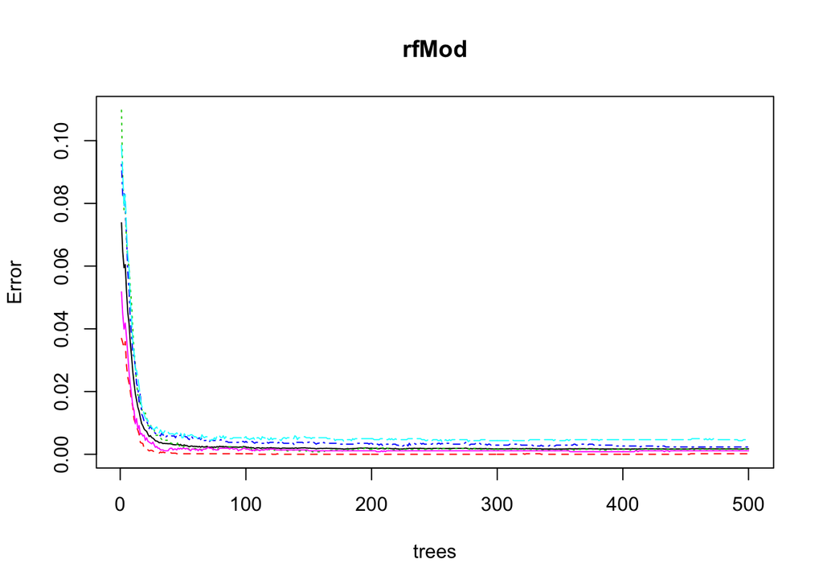

### IV. Variable Importance

One of the advantages of simple tree based methods is that there is one resulting decision tree which, perhaps after some pruning, makes it easy to determine which variables are important. In random forest multiple tree are used making it difficult to determine which variables are important. Fortunately, random forest provides a simple way to assess the importance of each predictor based on the mean decrease in accuracy and the mean decrease in the GINI coefficient due to splits over a given predictor. The larger the value the more important the predictor. The table below shows the mean decrease in the accuracy and GINI coefficients:

```r
importance(rfMod)[,c(6,7)]
```

```
##                     MeanDecreaseAccuracy MeanDecreaseGini
## num_window                         50.34          1318.65
## roll_belt                          53.82          1052.20
## pitch_belt                         46.10           631.19
## yaw_belt                           59.62           827.91
## total_accel_belt                   19.96           230.61
## gyros_belt_x                       23.23            93.48
## gyros_belt_y                       20.95           107.02
## gyros_belt_z                       29.29           292.33
## accel_belt_x                       21.76           135.49
## accel_belt_y                       17.81           139.04
## accel_belt_z                       30.71           406.73
## magnet_belt_x                      31.44           242.37
## magnet_belt_y                      27.89           370.84
## magnet_belt_z                      27.30           365.16
## roll_arm                           33.25           318.91
## pitch_arm                          22.32           167.45
## yaw_arm                            29.69           214.18
## total_accel_arm                    24.19            92.72
## gyros_arm_x                        26.13           117.44
## gyros_arm_y                        32.18           125.14
## gyros_arm_z                        20.45            49.59
## accel_arm_x                        19.89           221.08
## accel_arm_y                        26.29           135.95
## accel_arm_z                        22.28           118.73
## magnet_arm_x                       18.96           255.56
## magnet_arm_y                       18.11           207.20
## magnet_arm_z                       24.06           158.42
## roll_dumbbell                      31.52           396.76
## pitch_dumbbell                     17.47           181.32
## yaw_dumbbell                       26.73           246.80
## gyros_dumbbell_x                   28.26           114.23
## gyros_dumbbell_y                   25.03           231.91
## gyros_dumbbell_z                   36.38            72.06
## accel_dumbbell_x                   26.37           258.96
## accel_dumbbell_y                   38.68           413.84
## accel_dumbbell_z                   32.42           350.34
## magnet_dumbbell_x                  27.75           458.59
## magnet_dumbbell_y                  37.70           652.41
## magnet_dumbbell_z                  46.38           667.87
## roll_forearm                       27.85           521.14
## pitch_forearm                      40.92           728.89
## yaw_forearm                        27.59           159.47
## total_accel_forearm                22.35            93.98
## gyros_forearm_x                    31.33            71.17
## gyros_forearm_y                    33.84           113.73
## gyros_forearm_z                    33.91            72.38
## accel_forearm_x                    24.91           305.70
## accel_forearm_y                    26.51           127.06
## accel_forearm_z                    29.63           235.39
## magnet_forearm_x                   21.85           185.91
## magnet_forearm_y                   26.72           202.75
## magnet_forearm_z                   33.64           255.99
```

We can get a better sense of this data by the predictors by the mean decrease in accuracy and GINI coefficients

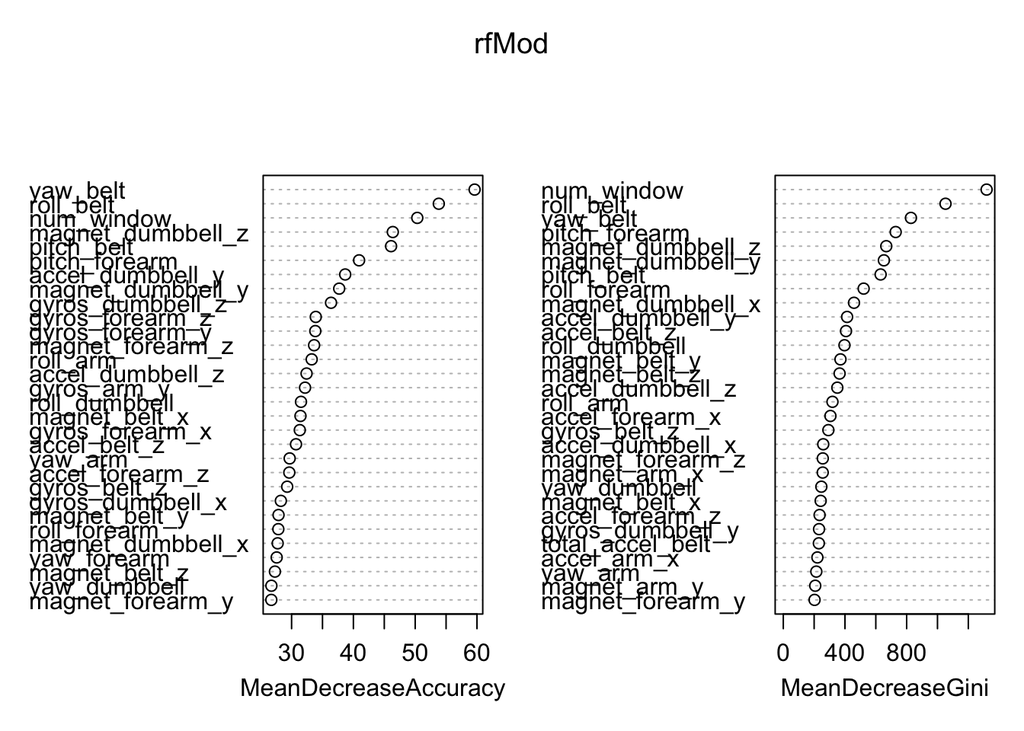

```r
varImpPlot(rfMod)
```

These plots suggest that a model built uisng only the most important predictors might be just as good as our full model. In fact, if we look at the means

```r
mean(importance(rfMod)[,"MeanDecreaseAccuracy"])
```

```
## [1] 29.5
```

```r
mean(importance(rfMod)[,"MeanDecreaseGini"])
```

```
## [1] 298.3
```

and express the mean values of the decrease in accuracy and GINI coefficients expressed relative to their maximum values, the resulting values,0.4948 and 0.2263

give us a sense of how small the mean values are to their corrsponding maximums which in turn suggests that the predictions of our model are dominated by just the largest terms.

Furthermore if we examine the standard devations and quantiles of the accuracy and GINI coefficients:

```r
sd(importance(rfMod)[,"MeanDecreaseAccuracy"])
```

```
## [1] 9.147
```

```r
quantile(importance(rfMod)[,"MeanDecreaseAccuracy"])
```

```
##    0%   25%   50%   75%  100%
## 17.47 23.01 27.67 32.63 59.62
```

```r
sd(importance(rfMod)[,"MeanDecreaseGini"])
```

```
## [1] 256.5
```

```r
quantile(importance(rfMod)[,"MeanDecreaseGini"])
```

```
##      0%     25%     50%     75%    100%
##   49.59  126.58  225.85  366.58 1318.65
```

we see that the wide distribution of both the accuracy and GINI coefficients also suggests that a model with fewer predictors might do as well as the full model. This idea is explored in section V.

### V. Predictions

First we test our full model, which according to our error estimates should be (and were!) very accurate

```r
testing<-read.csv("pml-testing.csv")
testingFiltered<-testing[c(7,8,9,10,11,37,38,39,40,41,42,43,44,45,46,47,48,49,60,61,62,63,64,65,66,67,68,84,85,86,113,114,115,116,117,118,119,120,121,122,123,124,140,151,152,153,154,155,156,157,158,159,160)]
rfTestPred<-predict(rfMod,newdata=testingFiltered)
rfTestPred
```

```
##  1  2  3  4  5  6  7  8  9 10 11 12 13 14 15 16 17 18 19 20
##  B  A  B  A  A  E  D  B  A  A  B  C  B  A  E  E  A  B  B  B
## Levels: A B C D E
```

Next we test a much smaller model, using the top 3 predictors and get identical results.

```r
trainingTop3<-training[c(7,8,10,160)]
testingTop3<-testing[c(7,8,10)]
rfModTop3<-randomForest(classe~.,data=trainingTop3,mtry=2,importance=TRUE)
rfTestTop3<-predict(rfModTop3,newdata=testingTop3)
rfTestTop3
```

```
##  1  2  3  4  5  6  7  8  9 10 11 12 13 14 15 16 17 18 19 20
##  B  A  B  A  A  E  D  B  A  A  B  C  B  A  E  E  A  B  B  B
## Levels: A B C D E
```

The fact that the smaller model gives identical results to the full model is not suprising given our analysis in section IV. Although there is no sign of overfitting using the full model, by using a reduced model we get results which are more easily interpretable since we have isolated which variables are most important for predicting how well the barbell exercises are done.